# Transit Oreinted Development in Queens, New York, 2009-2020

Xinge Zhang

2022-09-15

## I. Introduction & Motivation

In its effort to achieve a “greener and greater New York” while accommodating one million new residents, Mayor Michael Bloomberg’s **PlaNYC2030** embraced transit-oriented development” – the concentration of new housing in neighborhoods with good access to the city’s subways and buses.

However, in the early days of the plan announcement , there was controversy over whether “transit-oriented” development should occur in New York City, where public transportation is nearly ubiquitous and the transit system is well developed. The project could hardly further increase or diversify the public transportation system and would only promote dense residential development near stations. In addition, the plan encourages off-street parking lots to meet residential demand, raising people’s concerns about the project’s ability to promote greater access to public transit and develope vibrant TOD areas with mixed-use sites.

Therefore, this project aims to provide an overview to observe the changes in indicators of TOD and Non-TOD areas from 2009-2020 since the implementation of **PlaNYC2030**, and to illustrate the significance of identifying TOD areas.

## II. Setup

#### Load packages and functions

```r
library(tidyverse)
library(tidycensus)
library(sf)
library(kableExtra)

options(scipen=999) # cite scientifically
options(tigris_class = "sf")

source("https://raw.githubusercontent.com/urbanSpatial/Public-Policy-Analytics-Landing/master/functions.r")

qBr <- function(df, variable, rnd) {
  if (missing(rnd)) {
    as.character(quantile(round(df[[variable]],2),
                          c(.01,.2,.4,.6,.8), na.rm=T))
  } else if (rnd == FALSE | rnd == F) {
    as.character(formatC(quantile(df[[variable]]), digits = 3),
                 c(.01,.2,.4,.6,.8), na.rm=T)
  }
}

q5 <- function(variable) {as.factor(ntile(variable, 5))}

palette5 <- c("#f0f9e8","#bae4bc","#7bccc4","#43a2ca","#0868ac")

palette2<- c("#ffffcc","#c2e699","#78c679","#31a354","#006837")
```

## III. Data Manipulation and Visualization

### 1. Data Wrangling

Three datasets were used in this project:

- **Census Data**: demographic variables from the ACS 2009 and 2020 for census tracts in New York, Queens County.
- **Subway Station Data**: Queens subway station in geojson format from the subway transit system
- **Subway Line Data**: Queens subway line in geojson format from the subway transit system

#### 1.1 Fetch Census Data

Variables we were interested in this projects are:

```r
acs_variable_list.2009 <- load_variables(2009, #year
                                         "acs5", #five year ACS estimates
                                         cache = TRUE)
acs_variable_list.2020 <- load_variables(2020, #year
                                         "acs5", #five year ACS estimates
                                         cache = TRUE)
tracts20 <-
  get_acs(geography = "tract",
          variables = c("B25026_001E","B02001_002E",
                        "B15001_050E","B15001_009E",
                        "B19013_001E", "B25058_001E",
                        "B06012_002E","B08301_010",
                        "B08301_001","B08128_041"),
          year=2020, state="New York",
          county="Queens", geometry=TRUE) %>%
  st_transform(26918) %>%
  dplyr::select( -NAME, -moe) %>%
  spread(variable, estimate) %>%
  rename(TotalPop = B25026_001,
         Whites = B02001_002,
         FemaleBachelors = B15001_050,
         MaleBachelors = B15001_009,
         MedHHInc = B19013_001,
         MedRent = B25058_001,
         TotalPoverty = B06012_002,
         TotalPublictransit = B08301_010,
         TotalTransit =B08301_001,
         TotalWalk =B08128_041,
         )%>%
  mutate(pctWhite = ifelse(TotalPop > 0, Whites * 100 / TotalPop, 0),
         pctBachelors = ifelse(TotalPop > 0, ((FemaleBachelors + MaleBachelors) * 100/ TotalPop), 0),
         pctPoverty = ifelse(TotalPop > 0, TotalPoverty * 100/ TotalPop, 0),
         pctNonveh = ifelse(TotalTransit> 0, (TotalWalk + TotalPublictransit) * 100 / TotalTransit, 0),
         year = "2020") %>%
  dplyr::select(-Whites,-FemaleBachelors,-MaleBachelors,-TotalPoverty)%>%
  replace_na(list(0,0))

tracts09 <-
  get_acs(geography = "tract",
          variables = c("B25026_001E","B02001_002E",
                        "B15001_050E","B15001_009E",
                        "B19013_001E", "B25058_001E",
                        "B06012_002E","B08301_010",
                    "B08301_019",
                        "B08301_001"),
          year=2009, state="New York",
          county="Queens", geometry=TRUE) %>%
  st_transform(26918) %>%
  dplyr::select( -NAME, -moe) %>%
  spread(variable, estimate) %>%
  rename(TotalPop = B25026_001,
         Whites = B02001_002,
         FemaleBachelors = B15001_050,
         MaleBachelors = B15001_009,
         MedHHInc = B19013_001,
         MedRent = B25058_001,
         TotalPoverty = B06012_002,
         TotalPublictransit = B08301_010,
         TotalWalk =B08301_019,
         TotalTransit = B08301_001,
         )%>%
  mutate(pctWhite = ifelse(TotalPop > 0, Whites * 100 / TotalPop, 0),
         pctBachelors = ifelse(TotalPop > 0, ((FemaleBachelors + MaleBachelors)* 100  / TotalPop), 0),
         pctPoverty = ifelse(TotalPop > 0, TotalPoverty * 100  / TotalPop, 0),
        pctNonveh = ifelse(TotalTransit> 0, (TotalWalk + TotalPublictransit) * 100 / TotalTransit, 0),
         year = "2009") %>%
  dplyr::select(-Whites,-FemaleBachelors,-MaleBachelors,-TotalPoverty)

# --- Combining 09 and 20 data ----

allTracts <- rbind(tracts09,tracts20)
```

#### 1.2 Load New York Transit Data

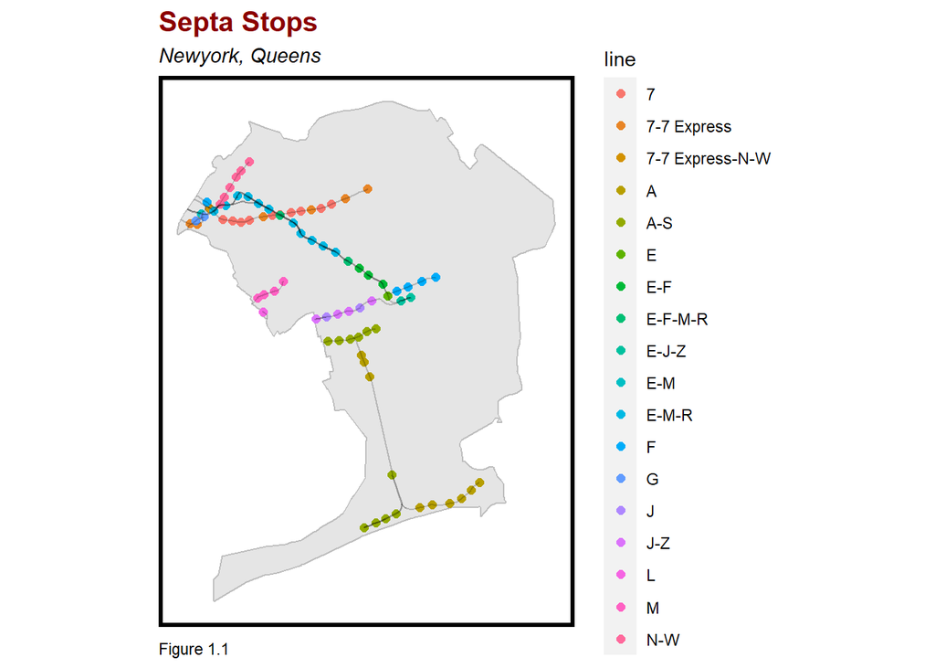

```r
septaStops <-
  st_read("~/Github/MUSA508_HW/DATA/Subway_Stations.geojson") %>%
  st_transform(st_crs(tracts20)) %>%
  st_intersection(st_union(tracts20)) %>%
  select(name, line)

septaLines <-
  st_read("~/Github/MUSA508_HW/DATA/Subway_Lines.geojson") %>%
  st_transform(st_crs(tracts20)) %>%
  st_intersection(st_union(tracts20)) %>%
  select(name, rt_symbol)

ggplot() +
  geom_sf(data=st_union(tracts20),fill = "grey90", color = "grey") +
  geom_sf(data=septaStops, aes(colour = line), show.legend = "point", size= 2) +
  geom_sf(data=septaLines, alpha=0.2)+
  labs(title="Septa Stops", subtitle="Newyork, Queens",caption = 'Figure 1.1') +
  mapTheme() +
  theme(plot.title = element_text(color = "darkred", size=15, face="bold"))
```

#### 1.3 Identifying TOD Tracts

With census data and transit data ready, let’s jump into TOD analysis! Compared to the textbook, I created a 0.25 mile buffer around the transit stops. This is because the subway stations are very dense throughout the area and I want to distinguish different regions. I tried the three different approaches for selecting tracts. (Figure 1.2) - intersection or clip - relate tracts and the buffer using the latter to cookie cutter the former - Spatial Selection - select all tracts that intersect or touch the buffer - Select by Centroids- select all the tract centroids that intersect the buffer

I select TOD tracts basedon select by Centroids because it both captures a concise set of tracts without altering geometries and the tracts it selected are more characteristic and focused.

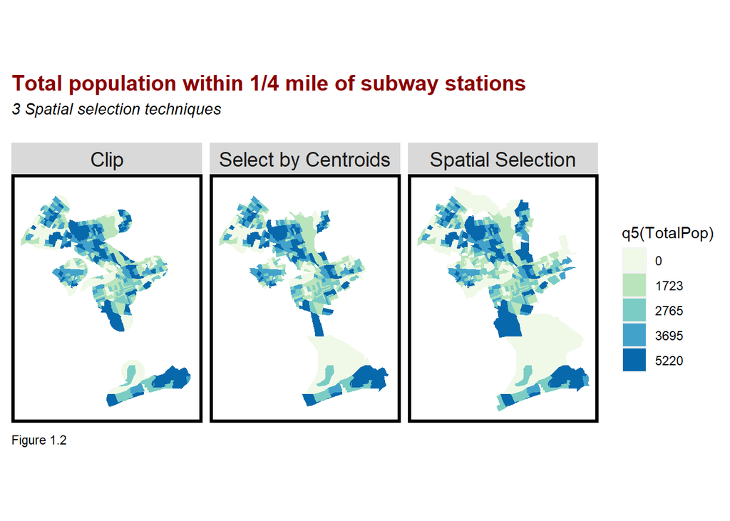

```r
D_Buffers <-
  rbind(
    st_buffer(septaStops, 1320) %>%
      mutate(Legend = "Buffer") %>%
      dplyr::select(Legend),
    st_union(st_buffer(septaStops, 1320)) %>%
      st_sf() %>%
      mutate(Legend = "Unioned Buffer"))
buffer <- filter(D_Buffers, Legend=="Unioned Buffer")

clip <-
  st_intersection(buffer, tracts09) %>%
    dplyr::select(TotalPop) %>%
    mutate(Selection_Type = "Clip")

selection <-
  tracts09[buffer,] %>%
    dplyr::select(TotalPop) %>%
    mutate(Selection_Type = "Spatial Selection")


selectCentroids <-
  st_centroid(tracts09)[buffer,] %>%
  st_drop_geometry() %>%
  left_join(dplyr::select(tracts09, GEOID)) %>%
  st_sf() %>%
  dplyr::select(TotalPop) %>%
  mutate(Selection_Type = "Select by Centroids")

selectCompare <- rbind(clip, selection, selectCentroids)

ggplot() +
  geom_sf(data=selectCompare, aes(fill = q5(TotalPop)), color = "transparent") +
  scale_fill_manual(values = palette5,labels = qBr(selectCompare, "TotalPop")) +
  labs(title = "Total population within 1/4 mile of subway stations",
       subtitle = "3 Spatial selection techniques\n",
       caption = 'Figure 1.2')+
  facet_wrap(~Selection_Type) +
  mapTheme() +
  theme(plot.title = element_text(color = "darkred", size=15, face="bold"))
```

Indicated in Figure 1.3.1, in the past 10 years, the overall Tod area did not change too much, which means there is no major transportation construction in the area. But there are still some changes due to the refinements and changes in population zoning.

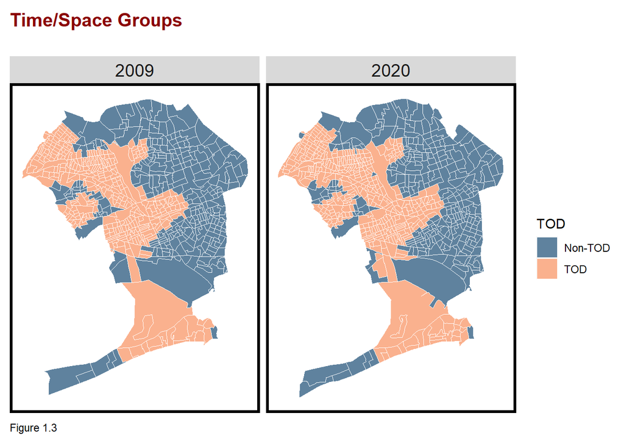

```r
# Census Data in Group by TODs
allTracts.group <-
  rbind(
    st_centroid(allTracts)[buffer,] %>%
      st_drop_geometry() %>%
      left_join(allTracts) %>%
      st_sf() %>%
      mutate(TOD = "TOD"),
    st_centroid(allTracts)[buffer, op = st_disjoint] %>%
      st_drop_geometry() %>%
      left_join(allTracts) %>%
      st_sf() %>%
      mutate(TOD = "Non-TOD")) %>%
  mutate(MedRent.inf = ifelse(year == "2009", MedRent * 1.14, MedRent))


# TOD and Non-TOD between 2009 and 2020
ggplot()+
  geom_sf(data = allTracts.group, aes(fill = TOD),color ="white", size =.3) +
  scale_fill_manual(values = c('#5f829e','#fab18e'))+
  labs(title = "Time/Space Groups",
       subtitle = '',
       caption = 'Figure 1.3') +
  facet_wrap(~year)+
  mapTheme() +
  theme(plot.title = element_text(color = "darkred", size=15, face="bold"))
```

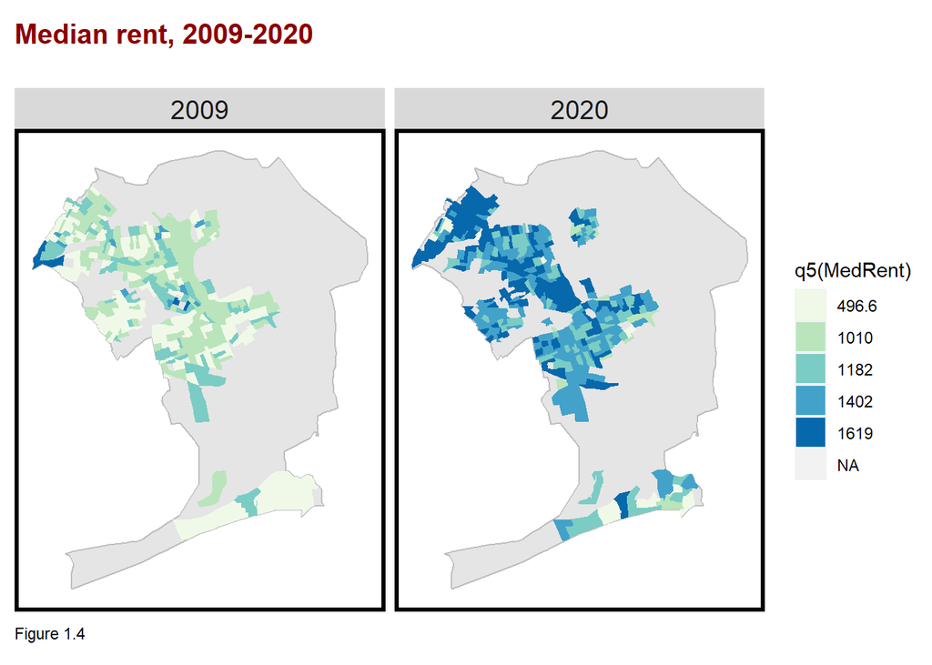

```r
# TOD and Non-TOD median rent between 2009 and 2020
ggplot(allTracts.group)+
  geom_sf(data = st_union(tracts09),fill = "grey90", color = "grey")+
  geom_sf(data = filter(allTracts.group, TOD == "TOD"),aes(fill = q5(MedRent)), color="transparent")+
  scale_fill_manual(values = palette5,
                    labels = qBr(allTracts.group, "MedRent"),
                    na.value = "transparent") +
  labs(title = "Median rent, 2009-2020",
       subtitle = '',
       caption = 'Figure 1.4') +
  facet_wrap(~year)+
  mapTheme() +
  theme(plot.title = element_text(color = "darkred", size=15, face="bold"))
```

### 2. Changes in Census Variables Over Time and Space

In Section 2, we examined the effects of time (years) and space (TOD vs non-TOD) on our four key Census variables:

- **Median rents**
- **Bachelor degree holders**
- **Median household income**
- Percentage of **White group**

Overall, from 2009 to 2020, the **Median rents** and **Median household income** increased largely but on Percentage of **White group** and **Bachelor degree holders** between two time are not very obvious.

#### 2.1 Median Rent Comparison between 2009 and 2020

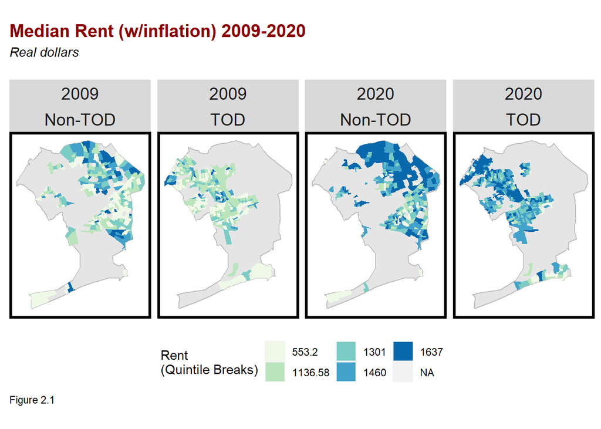

```r
ggplot(allTracts.group)+
  geom_sf(data = st_union(tracts09), fill = "grey90", color = "grey")+
  geom_sf(aes(fill = q5(MedRent.inf)), color = "transparent") +
  scale_fill_manual(values = c(palette5),
                    labels = qBr(allTracts.group, "MedRent.inf"),
                    name = "Rent\n(Quintile Breaks)",
                    na.value = "transparent") +
  labs(title = "Median Rent (w/inflation) 2009-2020",
       subtitle = "Real dollars \n",
       caption = 'Figure 2.1') +
 facet_wrap(c(~year,~TOD),ncol=4)+
  mapTheme() +
  theme(plot.title = element_text(color = "darkred", size=15, face="bold"),legend.position = "bottom")
```

#### 2.2 Percentage of White Group between 2009 and 2020

There was a decline between these two points in time, probably due to a larger population base and a larger foreign population, but it is still evident that whites were mostly concentrated in TOD areas, especially near transit stations.

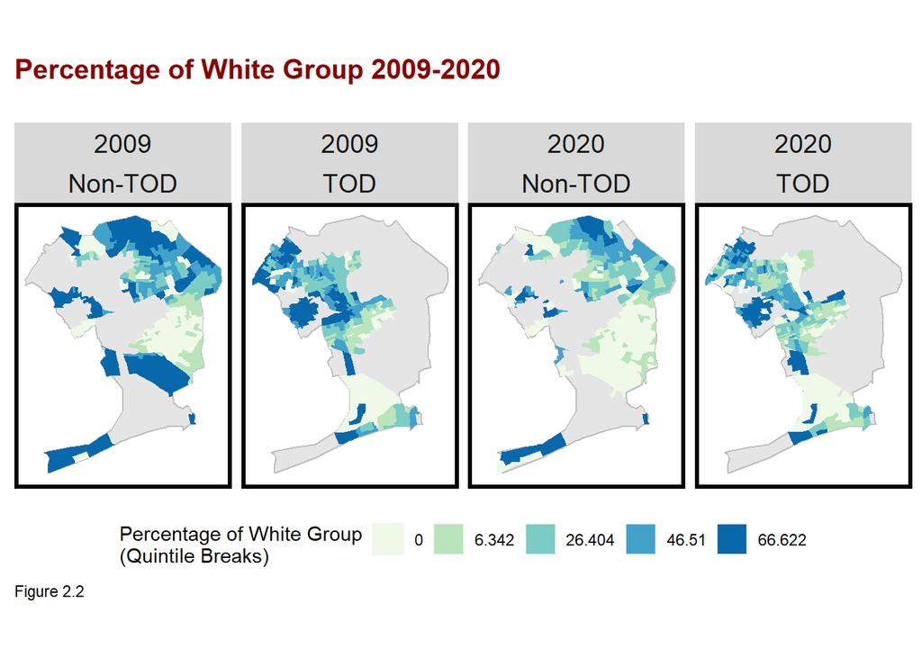

```r
ggplot(allTracts.group)+
  geom_sf(data = st_union(tracts09), fill = "grey90", color = "grey") +
  geom_sf(aes(fill = q5(pctWhite)), color = "transparent") +
  scale_fill_manual(values = palette5,
                    labels = qBr(allTracts.group, "pctWhite"),
                    name = "Percentage of White Group\n(Quintile Breaks)",
                    na.value = "transparent") +
  labs(title = "Percentage of White Group 2009-2020",
       subtitle = '',
       caption = 'Figure 2.2') +
  facet_wrap(c(~year,~TOD),ncol=4)+
  mapTheme() +
  theme(plot.title = element_text(color = "darkred", size=15, face="bold"),legend.position = "bottom")
```

#### 2.3 Bachelor Degree Comparison between 2009 and 2020

There was no major change in the overall rate, but people with a bachelor’s degree seemed to cluster near transit stations.

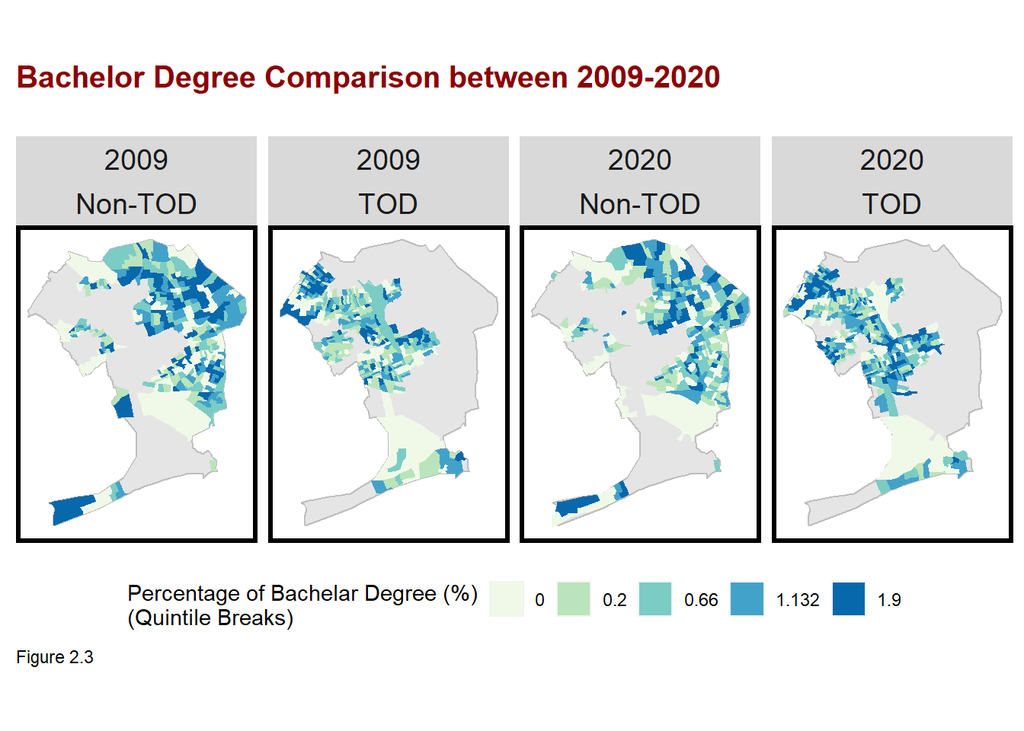

```r
ggplot(allTracts.group)+
  geom_sf(data = st_union(tracts09), fill = "grey90", color = "grey")+
  geom_sf(aes(fill = q5(pctBachelors)), color = "transparent") +
  scale_fill_manual(values = palette5,
                    labels = qBr(allTracts.group, "pctBachelors"),
                    name = "Percentage of Bachelar Degree (%)\n(Quintile Breaks)",
                    na.value = "transparent") +
  labs(title = "Bachelor Degree Comparison between 2009-2020",
       subtitle = '',
       caption = 'Figure 2.3') +
  facet_wrap(c(~year,~TOD),ncol=4)+
  mapTheme() +
  theme(plot.title = element_text(color = "darkred", size=15, face="bold"),legend.position = "bottom")
```

#### 2.4 Median Household Income Comparison between 2009 and 2020

Similar to Median Rent, the median household income increased largely and the increasing rate of TOD tracts was higher compared to non-TOD tracts.

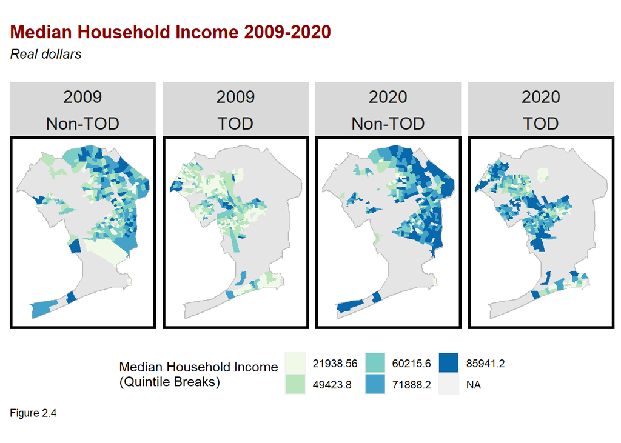

```r
ggplot(allTracts.group)+
  geom_sf(data = st_union(tracts09), fill = "grey90", color = "grey")+
  geom_sf(aes(fill = q5(MedHHInc)), color = "transparent") +
  scale_fill_manual(values = palette5,
                    labels = qBr(allTracts.group, "MedHHInc"),
                    name = "Median Household Income\n(Quintile Breaks)",
                    na.value = "transparent") +
  labs(title = "Median Household Income 2009-2020",
       subtitle = 'Real dollars \n',
       caption = 'Figure 2.4') +
 facet_wrap(c(~year,~TOD),ncol=4)+
  mapTheme() +
  theme(plot.title = element_text(color = "darkred", size=15, face="bold"),legend.position = "bottom")
```

### 3. Bar Plot Comparisons

Grouped bar plots would provide a more precise and direct approach of examining the four variables over time. Some highlights are provided as follows:

- Percentage of people with a **Bachelor’s degree** significantly increased for TOD tracts but decreased for those non-TOD tracts.
- **Median household income** of TOD tracts and non-TOD tracts both increased but interestingly, income of non-TOD tracts was higher than TOD-tracts all the way. Similar trend can also be found in terms of **median rent**! Interesting!
- **Population** of both non-TOD tracts and TOD tracts decreased and the variance in TOD tracts was greater!
- Percentage of **white group** decreased in both non-TOD tracts and TOD tracts. Besides, the white proportion in Tod tracts was much greater than that in non-TOD tracts all the way.

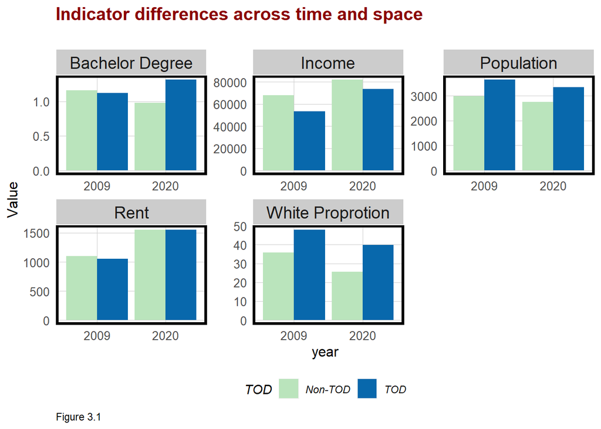

```r
allTracts.Summary <-
  st_drop_geometry(allTracts.group) %>%
  group_by(year, TOD) %>%
  summarize(Rent = mean(MedRent, na.rm = T),
            Population = mean(TotalPop, na.rm = T),
            `White Proprotion` = mean(pctWhite, na.rm = T),
            `Bachelor Degree` = mean(pctBachelors, na.rm = T),
            Income = mean(MedHHInc, na.rm = T))

allTracts.Summary %>%
  gather(Variable, Value, -year, -TOD) %>%
  ggplot(aes(year, Value, fill = TOD)) +
  geom_bar(stat = "identity", position = "dodge") +
  facet_wrap(~Variable, scales = "free", ncol = 3) +
  scale_fill_manual(values = c("#bae4bc","#0868ac")) +
  labs(title = "Indicator differences across time and space \n",
       caption = 'Figure 3.1') +
  plotTheme() +
  theme(legend.position="bottom") +
  theme(plot.title = element_text(color = "darkred", size=15, face="bold"))
```

### 4. Table Comparisons

Despite being indirect in terms of visualization, the comparison table still serves as a good approach of extracting the exact values. Some highlights indicated in Table 4.1:

```r
allTracts.Summary %>%
  unite(year.TOD, year, TOD, sep = ": ", remove = T) %>%
  gather(Variable, Value, -year.TOD) %>%
  mutate(Value = round(Value, 2)) %>%
  spread(year.TOD, Value) %>%
  kable() %>%
  kable_styling() %>%
  footnote(general_title = "\n",
           general = "Table 4.1")
```

| Variable | 2009: Non-TOD | 2009: TOD | 2020: Non-TOD | 2020: TOD |
| --- | --- | --- | --- | --- |
| Bachelor Degree | 1.16 | 1.12 | 0.98 | 1.31 |
| Income | 67745.26 | 53426.22 | 81906.39 | 73761.39 |
| Population | 2979.68 | 3641.67 | 2758.27 | 3335.79 |
| Rent | 1101.83 | 1056.31 | 1557.53 | 1556.75 |
| White Proprotion | 35.80 | 48.05 | 25.74 | 39.92 |

Table 4.1

### 5. Graduated Symbol Maps

From the previous analysis, we can see analysis based on the changes in median and sum from the table summary are very different from that based on the map plots. The table helps us to generalize the trend, but by map plotting we can clearly see that even within the TOD area, there are extreme differences between different tracts.

In this Chapter, I plotted the graduated population and rent within 0.25 miles of each transit station to clearly see the differences between different stations in the TOD tracts.

#### 5.1 Population within 0.25 mile of each transit station

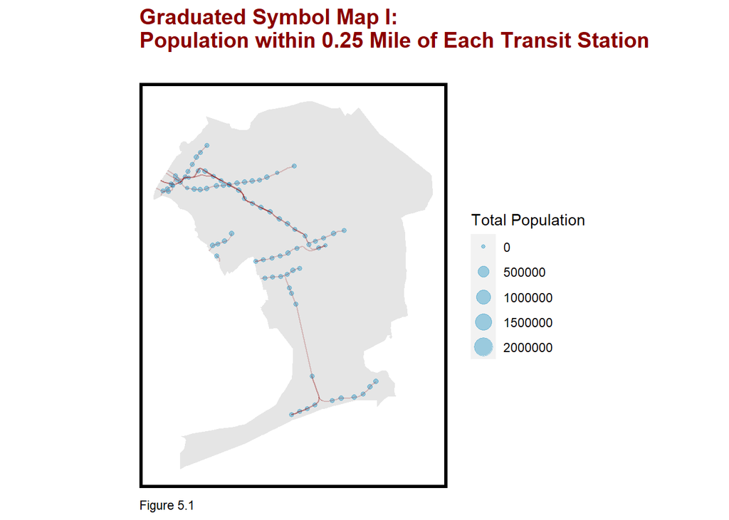

```r
popByStation <-
  join_data %>%
  group_by(name) %>%
  summarize(`Total Population` = sum(TotalPop)) %>%
  dplyr::select(name, `Total Population`) %>%
  st_drop_geometry() %>%
  left_join(septaStops)

popByStation_sf <- popByStation %>%
  st_sf()

ggplot() +
  geom_sf(data = allTracts.group, fill = "grey90", color = "transparent") +
  geom_sf(data = popByStation_sf, aes(size = `Total Population`), color = '#43a2ca' ,alpha=0.5) +
  geom_sf(data=septaLines, alpha=0.2,color = "darkred")+
  labs(title = "Graduated Symbol Map I: \nPopulation within 0.25 Mile of Each Transit Station" ,
       subtitle = '',
       caption = "Figure 5.1",
       fill = 'Total Population') +
  mapTheme() +
  theme(legend.position="right") +
  theme(plot.title = element_text(color = "darkred", size=15, face="bold"))
```

#### 5.2 Median rent within 0.25 mile of each transit station

We can also find transit stations with multiple lines intersecting with a higher rent, indicated in Figure 5.2. Accordingly, **there is no direct relationship between population and rent between different stations.** However, the density of stations might be an influence factor since we noticed there was inconsistency in indicators between TOD tracts in the previous plots.

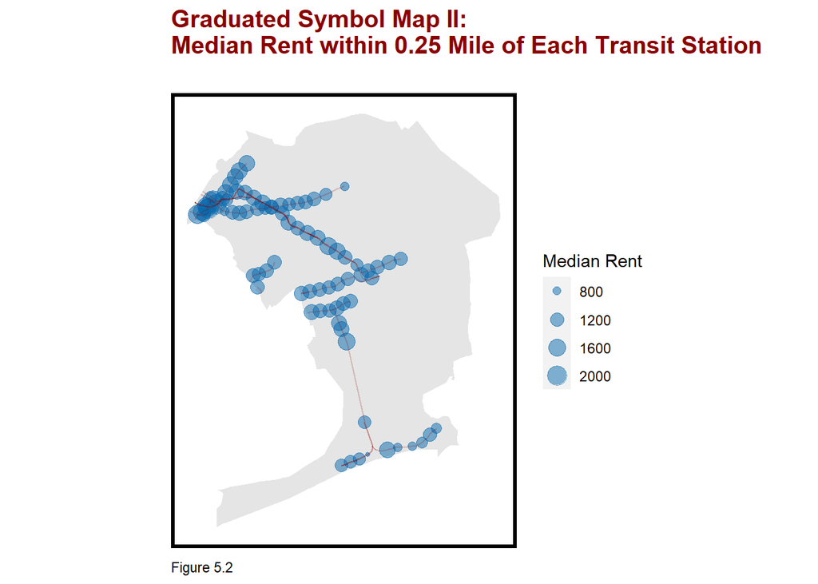

```r
rentByStation <-
  join_data %>%
  group_by(name) %>%
  summarize(`Median Rent` = median(na.omit(MedRent))) %>%
  dplyr::select(name, `Median Rent`)  %>%
  st_drop_geometry() %>%
  left_join(septaStops)

rentByStation_sf <- rentByStation %>%
  st_sf()

ggplot() +
  geom_sf(data = septaLines) +
  geom_sf(data = allTracts.group, fill = "grey90", color = "transparent") +
  geom_sf(data = rentByStation_sf, aes(size = `Median Rent`), color = '#0868ac',alpha=0.5)  +
  geom_sf(data=septaLines, alpha=0.2,color = "darkred")+
  labs(title = "Graduated Symbol Map II: \nMedian Rent within 0.25 Mile of Each Transit Station",
       subtitle = '',
       caption = "Figure 5.2") +
  mapTheme() +
  theme(legend.position="right") +
  theme(plot.title = element_text(color = "darkred", size=15, face="bold"))
```

### 6. Mean Rent as a function of distance to subway stations

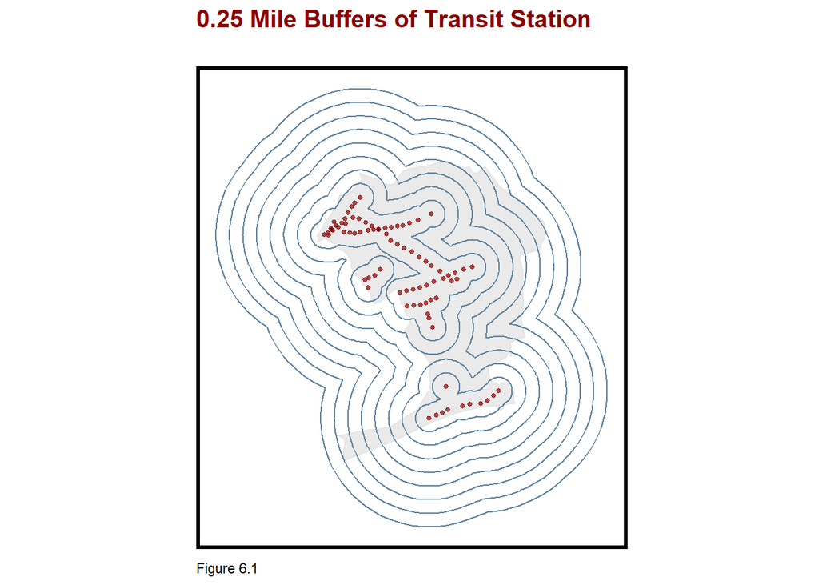

```r
ggplot() +
  geom_sf(data = st_union(tracts09), fill = "grey90",color = "grey90", alpha = 0.8)+
  geom_sf(data = multipleRingBuffer(st_union(septaStops), 10560, 1320),fill = "transparent", color = '#5f829e',size=0.5)+
  geom_sf(data=septaStops,  show.legend = "point",  color = 'darkred', size= 1,alpha = 0.7)+
  labs(title = "0.25 Mile Buffers of Transit Station",
       subtitle = '',
       caption = "Figure 6.1") +
  mapTheme() +
  theme(plot.title = element_text(color = "darkred", size=15, face="bold"))
```

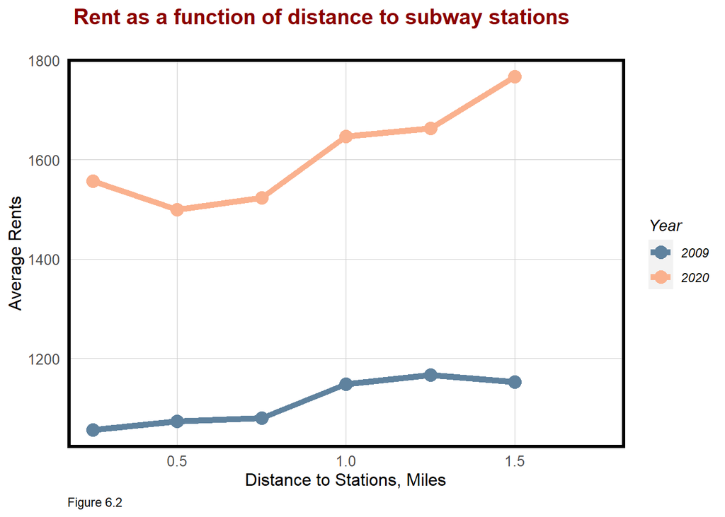

```r
allTracts.rings <-
  st_join(st_centroid(dplyr::select(allTracts, GEOID, year)),
          multipleRingBuffer(st_union(septaStops), 10560, 1320)
          ,join = st_intersects) %>%
  st_drop_geometry() %>%
  left_join(dplyr::select(allTracts, GEOID, MedRent, year),
            by=c("GEOID"="GEOID", "year"="year")) %>%
  st_sf() %>%
  mutate(distance = distance / 5280)

mean_RENT <- st_drop_geometry(allTracts.rings) %>%
  group_by(year, distance) %>%
  summarize(mean_RENT = mean(MedRent, na.rm = T))

ggplot(data = mean_RENT) +
  geom_line(aes(x = distance, y = mean_RENT, col = year), size = 2) +
  geom_point(aes(x = distance, y = mean_RENT, col = year) , size = 4) +
  labs(title = " Rent as a function of distance to subway stations",  subtitle = '',   caption = 'Figure 6.2') +
  scale_color_manual(values = c('#5f829e','#fab18e'),
                     name = 'Year') +
  theme(legend.position = "right") +
  xlab("Distance to Stations, Miles") +
  ylab("Average Rents") +
  plotTheme() +
  theme(plot.title = element_text(color = "darkred", size=15, face="bold"))
```

### 7. Public Transit Use within TOD area

There was a finding in previous studies that *“people increasingly tend to live in walkable, dense, mixed-use neighborhoods with access to public transportation - which is exactly what TOD provides.”* In this chapter, we will explore data on public transportation. The main indicator we use is the percentage of people using public transportation modes.

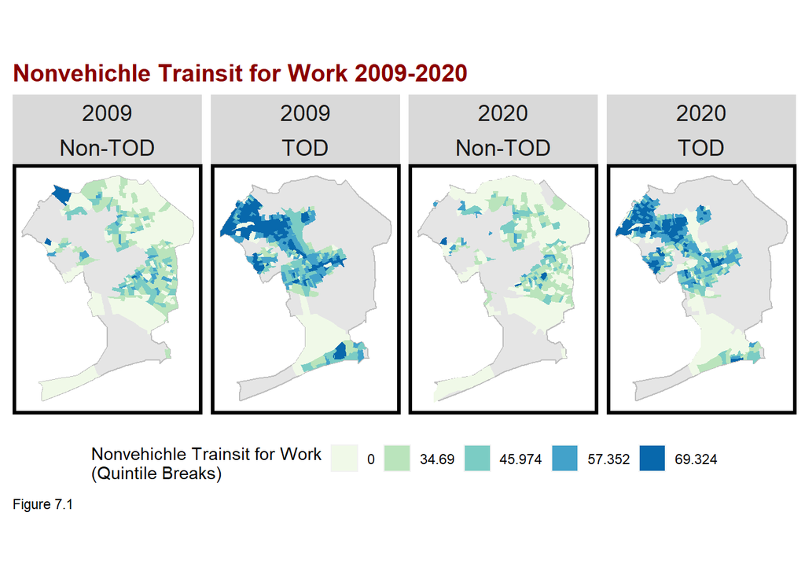

```r
ggplot(allTracts.group)+
  geom_sf(data = st_union(tracts09), fill = "grey90", color = "grey")+
  geom_sf(aes(fill = q5(pctNonveh)), color = "transparent") +
  scale_fill_manual(values = palette5,
                    labels = qBr(allTracts.group, "pctNonveh"),
                    name = "Nonvehichle Trainsit for Work\n(Quintile Breaks)") +
  labs(title = "Nonvehichle Trainsit for Work 2009-2020",
       caption = 'Figure 7.1') +
 facet_wrap(c(~year,~TOD),ncol=4)+
  mapTheme() +
  theme(plot.title = element_text(color = "darkred", size=15, face="bold"),legend.position = "bottom")
```

## IV. Conclusion and Recommandation

Despite a plausible plan, the construction of TOD areas still needs to take up some challenges and address existing problems. For instance, Queens is the second most populous of the five New York City boroughs. Approximately 47 percent of the residents of Queens are foreign-born. It is necessary that planners and policy makers pay attention to the **opportunity equity** for different group of people. Meanwhile, the government should control the rapid increase of rent compared to the increase of household income, otherwise, despite being willing to live in TOD areas, residents cannot afford the crazy rent. It’s also worth paying attention to the **spatial biases** could have on the result of this project since the areas of high rent could be clustering for reasons completely unrelated to transit development but to other policy-driven reasons.

In the future, with the development of technology and the prevalence of the **share economy**, planners and city builders need to consider urban forms and policy orientations that adapt to the development of the technology economy. Also, future transiy-oriented development may not be limited to rail transit stations, it might take the form of a more **integrated transportation node**, and we need more spatial research and future imagination based on this.

## Ⅴ. Reference：

- NYC Open Data, Subway lines dataset, geojson, https://data.cityofnewyork.us/Transportation/Subway-Lines/3qz8-muuu
- NYC Open Data, Subway stations dataset, geojson, https://data.cityofnewyork.us/Transportation/Subway-Stations/arq3-7z49
- Wikipedia.”Queens”, https://en.wikipedia.org/wiki/Queens
- MTA.”Transit-Oriented Development Program”, https://new.mta.info/agency/construction-and-development/transit-oriented-development
- “PlaNYC 2030 - A Greener Greater New York”, http://www.nyc.gov/html/planyc/downloads/pdf/publications/planyc_2011_planyc_full_report.pdf
- Stuart Lerner, *“TOD: How New York got it right”*, Railway Age, March 11, 2019, https://www.railwayage.com/news/tod-how-new-york-got-it-right/
- Brian Paul, *“How ‘Transit-Oriented Development’ Will Put More New Yorkers in Cars”*, Last modified April 21, 2010, https://www.gothamgazette.com/index.php/development/501-how-transit-oriented-development-will-put-more-new-yorkers-in-cars